# Explantory_Bay_wheel

## Factors affecting Bay wheels bike sharing

### Dataset Overview

Bay wheels -previously Ford GoBike- is large-scale bicycle sharing system deployed in California and on the West Coast of the United States ,Bay wheels like have a large fleet of sturdy and durable bikes that can be used then be locked into a docking station from the huge network of docking stations that are distributed throughout the city.The dataset used for this exploratory analysis is the newest published dataset as of Jul 6th 2020, 02:29:56 am , you can find it here : https://s3.amazonaws.com/baywheels-data/202006-baywheels-tripdata.csv.zip .

> The dataset originally includes 158168 Trips with 13 attributes / columns:  
> -ride_id  
> -rideable_type -started_at -ended_at  
> -start_station_name  
> -start_station_id  
> -end_station_name  
> -end_station_id -start_lat  
> -start_lng  
> -end_lat  
> -end_lng  
> -member_casual

### Investigation overview

> In this investigation , I want to higlight the most affecting factors on bike sharing , The main focus will be on days of month and customer membership and also the duration of trip

```python
# import all packages and set plots to be embedded inline
import numpy as np
import pandas as pd
import matplotlib.pyplot as plt
import seaborn as sb

%matplotlib inline
```

```python
#import the dataset
df = pd.read_csv("/content/drive/My Drive/Project Template/202006-baywheels-tripdata.csv")
```

```python
df['ended_at'] = pd.to_datetime(df['ended_at']) # transfer column from string datatype to datetime
df['started_at'] = pd.to_datetime(df['started_at']) # transfer column from string datatype to datetime
#let's add new column indicating the duration of our ride
df["ride_duration"]=df['ended_at']-df['started_at'] #The duration is endtime - starttime
df['year'] = pd.DatetimeIndex(df['started_at']).year # get the year and put it in a new column
df['month'] = pd.DatetimeIndex(df['started_at']).month # get the month and put it in a new column
df['day'] = pd.DatetimeIndex(df['started_at']).day # get the day and put it in a new column
df['weekend'] = (df['day']// 5 == 1) # create a column to indicate whether a weekend or not
rides_dur_in_hours= (df.ride_duration.dt.total_seconds()/(60*60)).astype(int) # covert ride
                                          #duration to seconds and then convert it in terms of hours
df['ride_duration_in_hours']=rides_dur_in_hours # make a feature with duration in hours
df['ride_duration_in_hours'].value_counts() # get value counts
df.head() # Preview the head to see if changes take place
```

|  | ride_id | rideable_type | started_at | ended_at | start_station_name | start_station_id | end_station_name | end_station_id | start_lat | start_lng | end_lat | end_lng | member_casual | ride_duration | year | month | day | weekend | ride_duration_in_hours |
| --- | --- | --- | --- | --- | --- | --- | --- | --- | --- | --- | --- | --- | --- | --- | --- | --- | --- | --- | --- |
| 0 | 08A4A9F7315901F3 | electric_bike | 2020-06-03 16:37:10 | 2020-06-03 16:48:28 | NaN | NaN | NaN | NaN | 37.770000 | -122.40000 | 37.760000 | -122.420000 | casual | 00:11:18 | 2020 | 6 | 3 | False | 0 |
| 1 | 844F9D906468C441 | electric_bike | 2020-06-03 12:22:47 | 2020-06-03 12:44:02 | NaN | NaN | NaN | NaN | 37.780000 | -122.49000 | 37.780000 | -122.460000 | casual | 00:21:15 | 2020 | 6 | 3 | False | 0 |
| 2 | 0E441BF8A86C544E | electric_bike | 2020-06-02 17:37:43 | 2020-06-02 17:52:21 | Powell St at Columbus Ave | 487.0 | NaN | NaN | 37.800426 | -122.41095 | 37.790000 | -122.440000 | casual | 00:14:38 | 2020 | 6 | 2 | False | 0 |
| 3 | CAFE64864422F475 | electric_bike | 2020-06-02 18:13:01 | 2020-06-02 18:48:30 | NaN | NaN | NaN | NaN | 37.760000 | -122.41000 | 37.770000 | -122.430000 | casual | 00:35:29 | 2020 | 6 | 2 | False | 0 |
| 4 | 172957A20160D568 | electric_bike | 2020-06-03 15:16:06 | 2020-06-03 16:06:10 | Church St at Duboce Ave | 85.0 | 48th Ave at Cabrillo St | 521.0 | 37.769841 | -122.42921 | 37.772894 | -122.509079 | casual | 00:50:04 | 2020 | 6 | 3 | False | 0 |

### Days of month effect on rides

> It is noticed that most days of demand are 13,6,3 with nearly the same trips

> It is noticed that that big part of long duration trips is located in the first 10 days of the month ,and from 10 to 20 very small number of high duration trips are done ,We can also see that the long duration trips tend to increase at days 21-27 then decreaes again

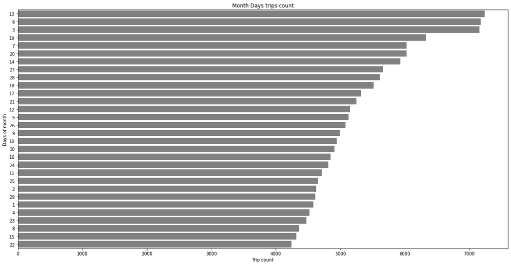

```python
plt.figure(figsize = [20,10]) #choose larger figure size to make it bigger and more clear
sb.countplot(data=df, y='day', color="grey" , order = df.day.value_counts().index); # create a countplot
plt.ylabel('Days of month');#identify x axis label
plt.xlabel('Trip count');#identify y axis label
plt.title("Month Days trips count") ; #create title for the plot
```

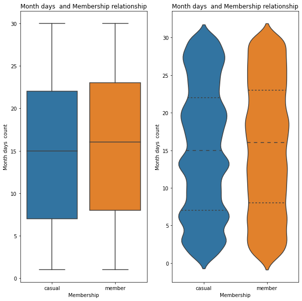

```python
plt.figure(figsize=[10,10])#choose larger figure size to make it bigger and more clear
plt.subplot(1,2,1)# make subplots to view two plots side to side
#First subplot is boxplot

sb.boxplot(data=df,  x=df.member_casual, y=df.day ); # create a boxplot

plt.xlabel('Membership');#identify x axis label
plt.ylabel('Month days  count');#identify y axis label
plt.title('Month days  and Membership relationship');#create title for the plot


plt.subplot(1,2,2)
#Second subplot is violinplot

sb.violinplot(data=df,  x=df.member_casual, y=df.day , inner = "quartile"); # create a violinplot

plt.xlabel('Membership');#identify x axis label
plt.ylabel('Month days  count');#identify y axis label
plt.title('Month days  and Membership relationship');#create title for the plot
```

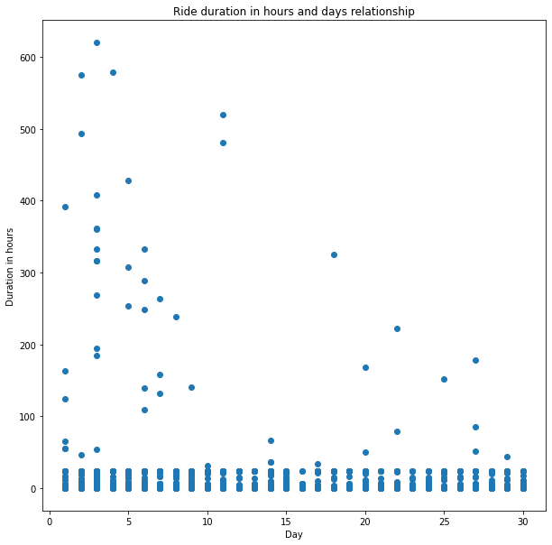

```python
plt.figure(figsize=[10,10]) #choose larger figure size to make it bigger and more clear

plt.scatter(data=df, y='ride_duration_in_hours',  x='day' ); # create scatter plot

plt.xlabel('Day'); # create label for x-axis
plt.ylabel(' Duration in hours '); # create label for y-axis
plt.title('Ride duration in hours and days relationship');# create Title for plot
```

#### Trips According to weekend or not

> For eveyone surprise trips tend to be more on non-weekend days than weekend ones by a huge difference with nearly 83 % of the rides done in non-weekend days

> Casual users tend to have more trips in non-wweekend days than riders whom are members

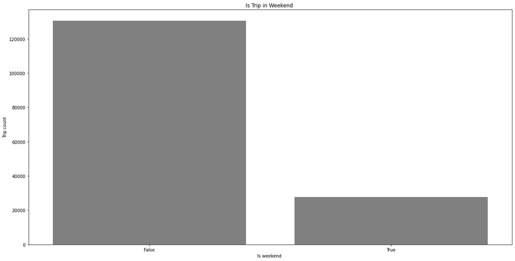

```python
plt.figure(figsize = [20,10]) #choose larger figure size to make it bigger and more clear
sb.countplot(data=df, x='weekend', color="grey" , order = df.weekend.value_counts().index); # create a countplot
plt.xlabel('Is weekend ');#identify x axis label
plt.ylabel('Trip count');#identify y axis label
plt.title("Is Trip in Weekend ") ;#create title for the plot
```

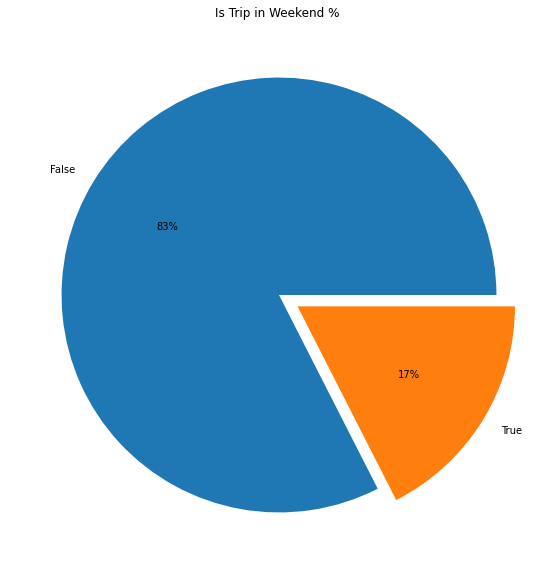

```python
plt.figure(figsize = [20,10]) #choose larger figure size to make it bigger and more clear
plt.pie(data=df, x=df.weekend.value_counts() , labels=["False","True"]
        ,autopct='%1.0f%%' , explode = (0 ,0.1)); # create a pie chart
plt.title("Is Trip in Weekend % ") ;#create title for the plot
```

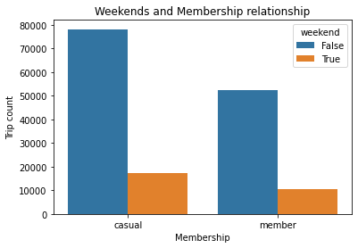

```python
sb.countplot(data=df, hue='weekend',x =df.member_casual  ); # create a countplot

plt.xlabel('Membership');#identify x axis label
plt.ylabel('Trip count');#identify y axis label
plt.title('Weekends and Membership relationship');#create title for the plot
```

#### Trips according to customer membership type

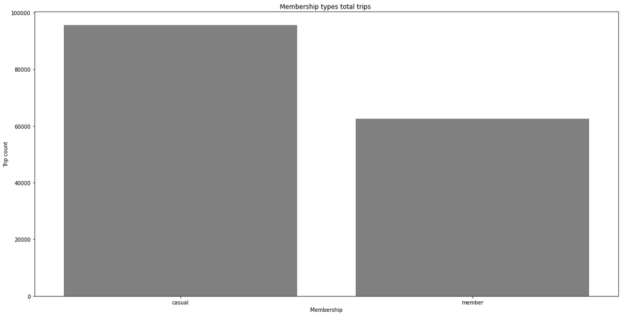

```python
plt.figure(figsize = [20,10]) #choose larger figure size to make it bigger and more clear
sb.countplot(data=df, x='member_casual', color="grey" , order = df.member_casual.value_counts().index); # create a countplot
plt.xlabel('Membership');#identify x axis label
plt.ylabel('Trip count');#identify y axis label
plt.title("Membership types total trips ") ;#create title for the plot
```

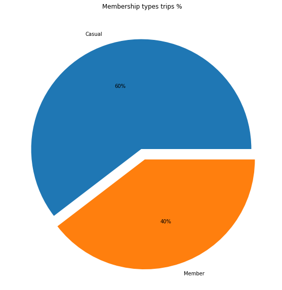

```python
plt.figure(figsize = [20,10]) #choose larger figure size to make it bigger and more clear
plt.pie(data=df, x=df.member_casual.value_counts() , labels=["Casual","Member"]
        ,autopct='%1.0f%%' , explode = (0 ,0.1)); # create a pie chart
plt.title(" Membership types trips %");#create title for the plot
```

#### Ride type effect on rides

> Looks like the most in demand bike type is the electric bike with nearly 70% of toal rides and only 31% to the docked bike type

> We can see that although electric bikes are used more frequent but they are only used for short durations of time , while long durations are done using docked bikes

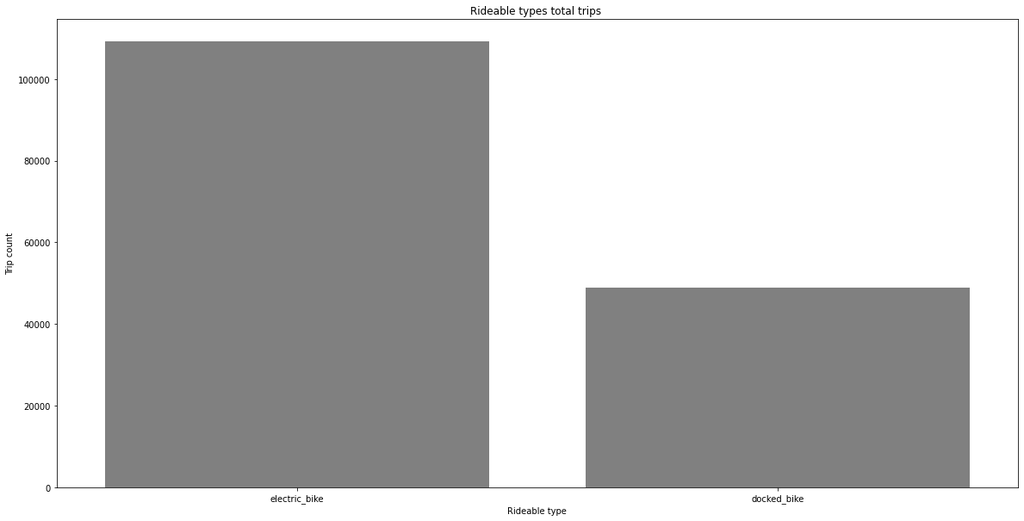

```python
plt.figure(figsize = [20,10]) #choose larger figure size to make it bigger and more clear
sb.countplot(data=df, x='rideable_type', color="grey" , order = df.rideable_type.value_counts().index); # create a countplot
plt.xlabel('Rideable type');#identify x axis label
plt.ylabel('Trip count');#identify y axis label
plt.title("Rideable types total trips ") ;#create title for the plot
```

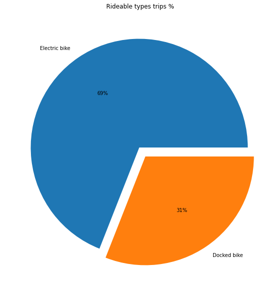

```python
plt.figure(figsize = [20,10]) #choose larger figure size to make it bigger and more clear
plt.pie(data=df, x=df.rideable_type.value_counts() , labels=["Electric bike ","Docked bike "]
        ,autopct='%1.0f%%' , explode = (0 ,0.1)); # create a pie chart
plt.title(" Rideable types trips %");#create title for the plot
```

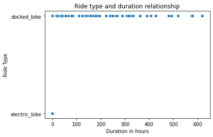

```python
sb.scatterplot(data=df, y=df.rideable_type, x=df.ride_duration_in_hours);# create scatter plott
plt.xlabel('Duration in hours'); # create label for x-axis
plt.ylabel('Ride Type');# create label for y-axis
plt.title('Ride type and duration relationship'); # create Title for plot
```

Most frequent trip durations amoung trips

> We can see that most of the trips are in the range of 0-1 hour(s)

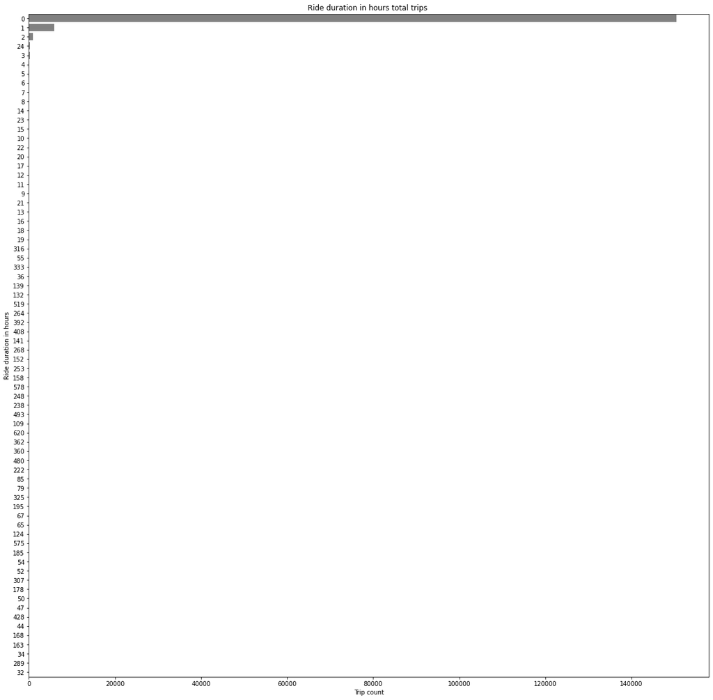

```python
plt.figure(figsize = [20,20]) #choose larger figure size to make it bigger and more clear
sb.countplot(data=df, y=df.ride_duration_in_hours, color="grey" , order = df.ride_duration_in_hours.value_counts().index); # create a countplot
plt.ylabel('Ride duration in hours');#identify x axis label
plt.xlabel('Trip count');#identify y axis label
plt.title("Ride duration in hours total trips ") ;#create title for the plot
```

#### Getting it all together

[figure not shown]

```python
plot = sb.catplot(data=df, x='rideable_type', hue='member_casual', y='day',
                  kind="violin", height=5, aspect=2); # create a catplot
plot.fig.suptitle('Ford GoBike System - Days of Month trips according to ride type and  Gender',
                  y=1.1, fontsize=10); # create a title for the plot and increase its font to be clear
plot.set_axis_labels("Ride Type","Day of Month "); # give the axes of the graph labels
                                                  #(x-axis label , y-axis label)
```

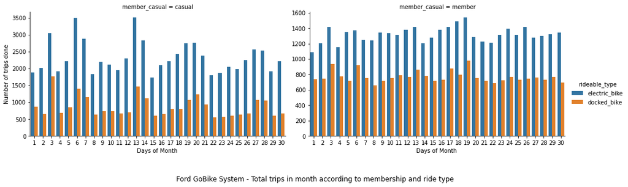

```python
plot = sb.catplot(data=df, x='day', col="member_casual", hue="rideable_type", kind='count',
                  sharey = False, height = 4 , aspect=1.75);# create a catplot
plot.fig.suptitle('Ford GoBike System - Total trips in month according to membership and ride type'
, y =-0.1);# create a title for the plot and move it down  to be more  clear
plot.set_axis_labels("Days of Month ", "Number of trips done");# give the axes of the graph labels
                                                  #(x-axis label , y-axis label)
```